# NHS Borders Cancer Incidence Report

This report details a number of insights into the trends of cancer incidence in the NHS Borders health board area.

### Overview of Cancer Trends in Scotland

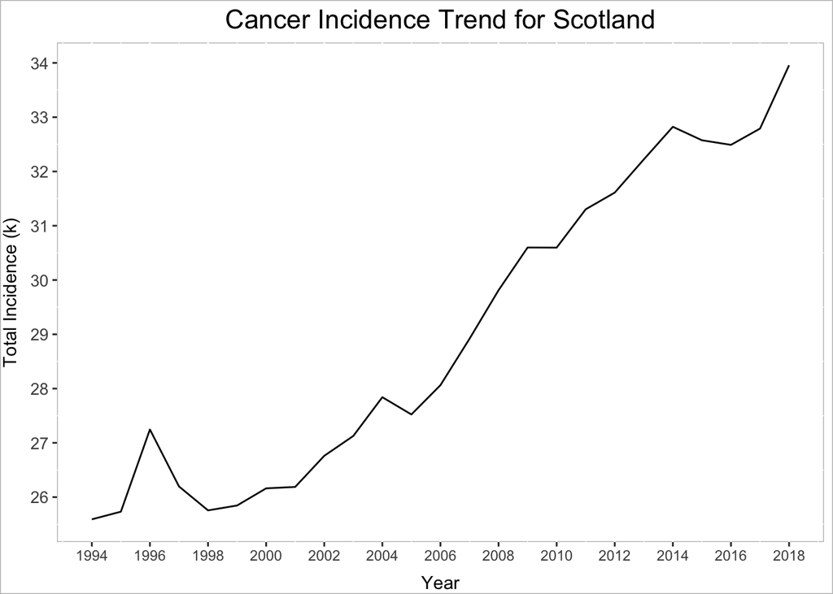

### Cancer Trends in NHS Borders

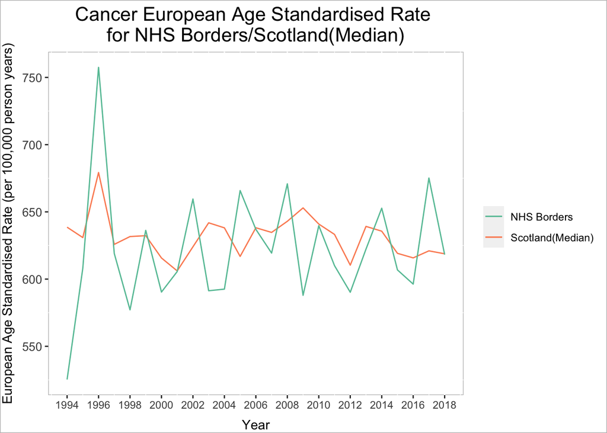

### Cancer Types (by Gender)

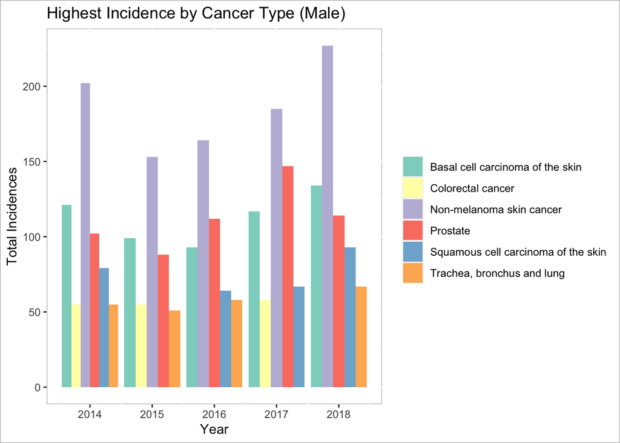

* Cancer types with highest incidence for men  
* Consistently been 6 major types, with non-melanoma skin cancer highest incidence

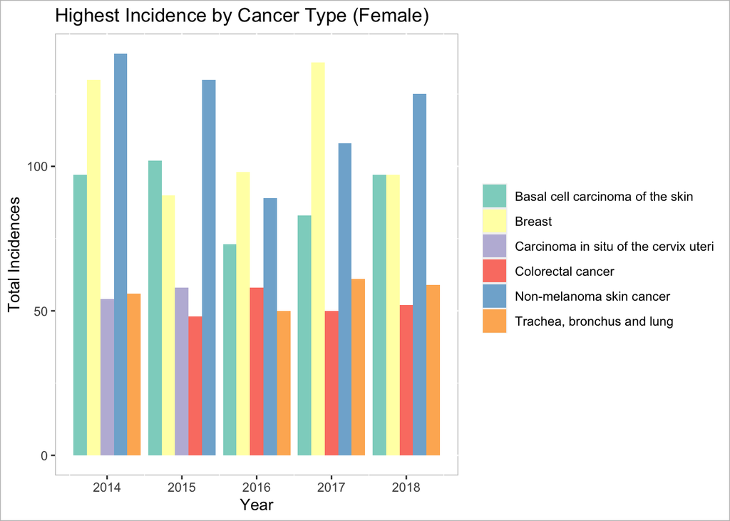

* Highest incidence cancer types have also been consistent in women  
* Non-melanoma skin cancer and breast cancer

### Cancer Incidence (Top 5 Cancer Sites)

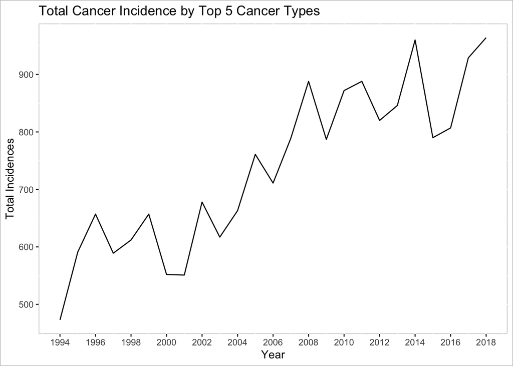

* Ideally, forecasting model would be used to predict incidence increase over next five years  
* Due to time pressure, this was not carried out  
* Overall incidence has shown upward trend over last few years  
* Estimated mean value of last 5 years = 3% increase  
* Planned available resources should take this increase into account for next year, including a margin of error

### Possible Further Work

* Increased domain knowledge would assist with grouping on cancer type  
* Review of NHS Borders waiting times for cancer treatment  
* Further exploration of any data on cancer survival because this could affect resource allocation